# 52414 - lab 1 Solutions

Idan Goldfarb & Omri Erez

6/4/2022

#### Analysis of the World Covid-19 Dataset

##1. First we will load the data and then list the top five dates for high income countries with most new cases, new deaths and new vaccinations.

```r
# Solution code in R:

# a. Loading the data

cases <- read.csv(url("https://raw.githubusercontent.com/owid/covid-19-data/master/public/data/owid-covid-data.csv"),comment.char="#")

# Modifying date

cases$date <- as.Date(cases$date)

# b. Listing five top dates

cases %>% filter(location == "High income") %>% group_by(new_cases,date) %>% summarise(new_cases = sum(new_cases)) %>% arrange(desc(new_cases)) %>% head(5) # top five by new cases
```

```
## # A tibble: 5 x 2
## # Groups:   new_cases [5]
##   new_cases date
##       <dbl> <date>
## 1   2830641 2022-01-19
## 2   2737975 2022-01-18
## 3   2589466 2022-01-10
## 4   2559046 2022-01-21
## 5   2532235 2022-01-26
```

```r
cases %>% filter(location == "High income") %>% group_by(new_deaths,date) %>% summarise(new_deaths = sum(new_deaths)) %>% arrange(desc(new_deaths)) %>% head(5) # top five by new deaths
```

```
## # A tibble: 5 x 2
## # Groups:   new_deaths [5]
##   new_deaths date
##        <dbl> <date>
## 1      11027 2021-01-20
## 2      10283 2021-01-26
## 3      10178 2021-01-12
## 4      10057 2021-01-27
## 5       9962 2021-01-08
```

```r
cases %>% filter(location == "High income") %>% group_by(new_vaccinations,date) %>% summarise(new_vaccinations = sum(new_vaccinations)) %>% arrange(desc(new_vaccinations)) %>% head(5) # top five by new vaccinations
```

```
## # A tibble: 5 x 2
## # Groups:   new_vaccinations [5]
##   new_vaccinations date
##              <dbl> <date>
## 1         12018802 2021-08-04
## 2          9758830 2021-12-17
## 3          9561412 2021-06-10
## 4          9528054 2021-06-09
## 5          9457785 2021-06-11
```

All top five date for new cases are in January 22, all top five date for new death are in January 21, the day with most vaccination is in August 21, the second day is in December 21 and the rest are in June 21.

##2. The function will get the Covid data and a column name, after filtering High and Low income countries it will make a plot using ggplot to show the difference between the two.

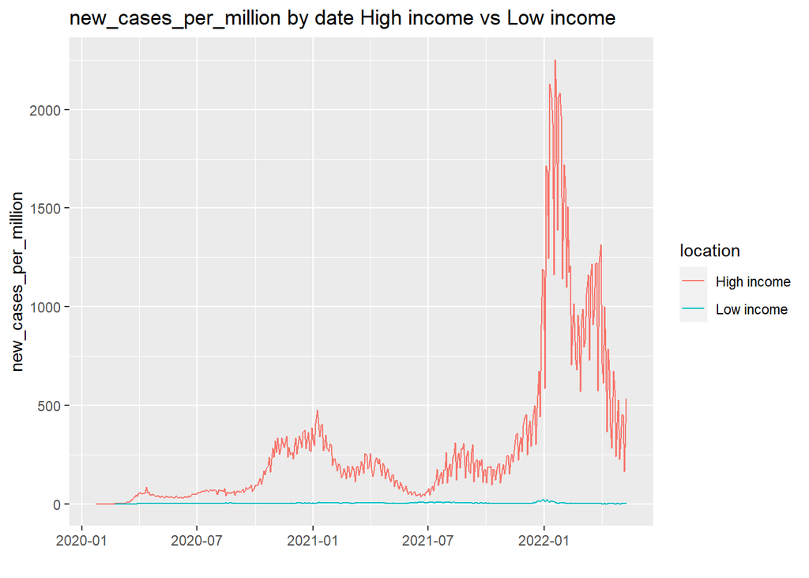

```r
# Solution code in R:

# a. Writing the function

plot_fun <- function(data_farme,column_name){
  new_data <- data_farme %>% filter(location == c("High income","Low income")) %>% select(location,date,column_name) # filtering High and Low income countries and the given column.
  new_data %>% ggplot(aes(x=date,y=new_data[[column_name]],col = location))+
  geom_line()+
  labs(
      title = paste(column_name,"by date High income vs Low income"),
      x = "",
      y = as.character(column_name),

    )

}

# b. plots for "new_cases_per_million", "new_cases_smoothed_per_million_log","new_deaths_smoothed_log" and "new_vaccinations_smoothed_per_million".

plot_fun(cases,"new_cases_per_million")
```

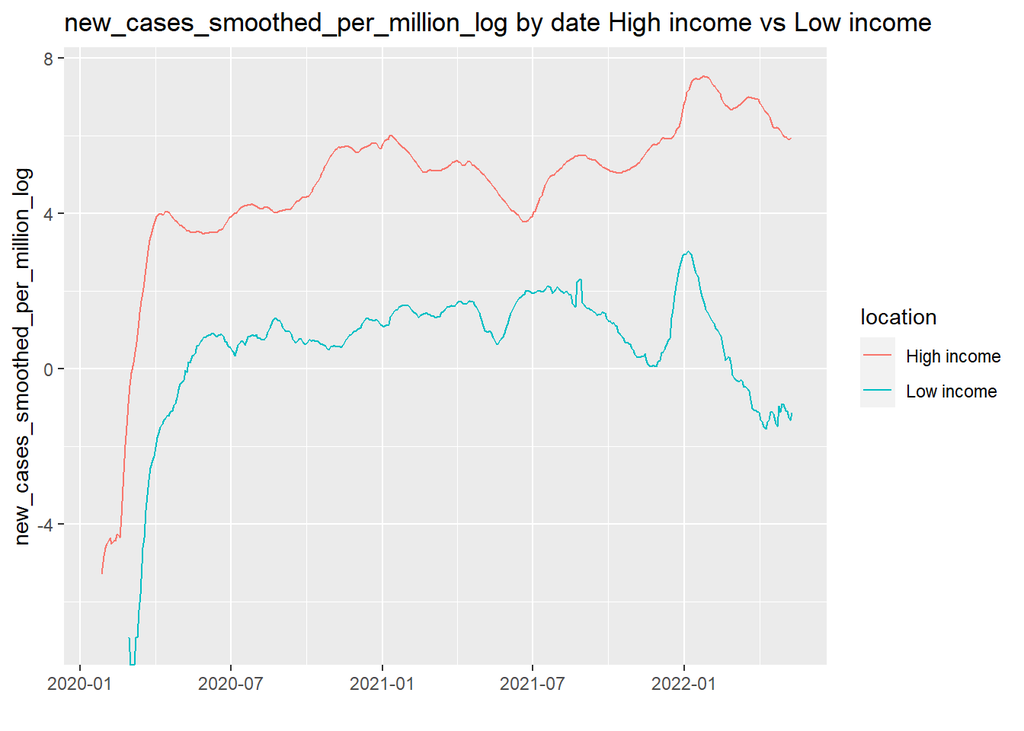

```r
new_cases_smoothed_per_million_log <- log(cases$new_cases_smoothed_per_million)


plot_fun(cbind(cases,new_cases_smoothed_per_million_log),"new_cases_smoothed_per_million_log")
```

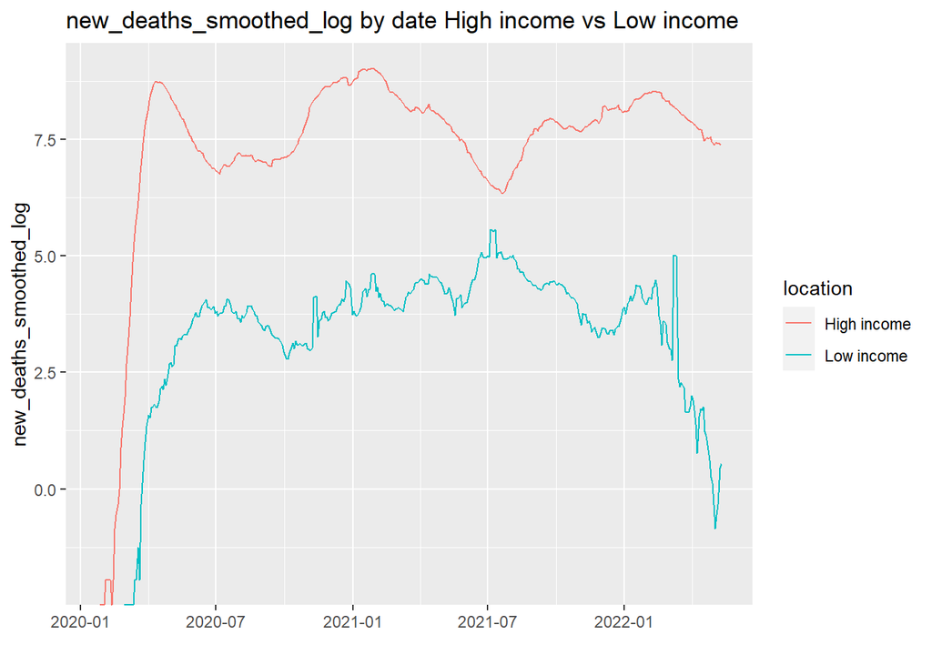

```r
new_deaths_smoothed_log <- log(cases$new_deaths_smoothed)

plot_fun(cbind(cases,new_deaths_smoothed_log),"new_deaths_smoothed_log")
```